# Preprocesamiento del dataset de sarcoma (GSE21050)

María Lourdes Linares Barrera

# Configuración de variables de script y directorio de trabajo

Establecemos como directorio de trabajo (workspace) el directorio en el que se encuentra el fichero.

```r
library(rstudioapi)

workspace_path <- rstudioapi::getActiveDocumentContext()$path
setwd(dirname(workspace_path))

print( paste("Workspace:",getwd()) )
```

Configuramos las variables del script para el conjunto de datos.

```r
# Caracteristicas de los datos

dataset_name <- "GSE21050"      # conjunto de datos
microarray_platform <- "hgu133plus2.db"  # plataforma de microarray (para sumarizacion)
not_gene_columns <- c("group","time_survivor")           # columas que no son sondas

# Acciones a realizar
do_log2 <- "YES"   # Estos datos ya se encuentran en intensidades log2
do_norm <- "NO"  # Estos datos no presentan a penas variabilidad experimental

# Carpeta donde almacenar ficheros y logs
dataset_files_folder_extraction <-
  paste0("P0_ficheros_extraccion_",dataset_name,"/")

dataset_files_folder_preprocessing <-
  paste0("P1_ficheros_preprocesamiento_",dataset_name,"/")
```

```r
# Parametros de configuracion de los graficos

# Bloxplot
nmax_boxplot <- 50

# Intensity plot
log2_xlim_before <- c(-1,15)
log2_ylim_before <- c(0,0.5)
log2_xlim_after <- c(-1,15)
log2_ylim_after <- c(0,0.5)

# Volcanoplot
volcano_legend <- "bottomleft"
volcano_cex <- 0.5
volcano_xlim <- c(-2,2)
volcano_ylim <- c(0,10)

# MDplot
md_legend <- "topright"
md_cex <- 0.8
md_xlim <- c(5,10)
md_ylim <- c(-2,2)

# UMAP plot
umap_cex <- 1.2
umap_legend <- "topright"
groupv0 <- "metastasis-no"    # nombre de las clases etiquetadas como 0 y 1
groupv1 <- "metastasis-yes"
```

# Importación de paquetes

Importamos los paquetes necesarios para el tratamiento de los dataframes, la carga de la base de datos ómica y el preprocesamiento génico de los datos.

```r
library(tidyverse)
library(dplyr)


library(GEOquery)
library(limma)
library(preprocessCore)
do.call("library", list(microarray_platform))
library(umap)
```

# Extracción de datos

Llamamos al script de extracción del conjunto de datos.

```r
script_extraccion <- sprintf("./0_extraccion_datos_%s.R", dataset_name)
source(script_extraccion)
```

```
## Found 1 file(s)
```

```
## GSE21050_series_matrix.txt.gz
```

[output not shown]

```r
dataset1 <- read_csv(paste0(dataset_files_folder_extraction,
                            dataset_name,"_1_notnulldata.csv"),
                     show_col_types = FALSE
                     )
gene_matrix1 <- dataset1[ , -which(names(dataset1) %in% not_gene_columns)]
not_gene_data1 <- dataset1[ ,c(not_gene_columns)]
```

# Intensidades log2

En datos ómicos de microarray, es habitual transformar los datos a escala logarítmica ya que facilita la comparación entre distintos experimentos o fuentes de datos al situar los datos en una escala común. No siempre es necesario aplicar este paso ya que, en muchas ocasiones, se proporcionan ya los datos en escala logarítmica.

```r
# Conversion a intensidades log2

if (do_log2=="YES"){

  qx <- as.numeric(quantile(t(gene_matrix1), c(0., 0.25, 0.5, 0.75, 0.99, 1.0), na.rm=T))
  LogC <- (qx[5] > 100) || (qx[6]-qx[1] > 50 && qx[2] > 0)

  if (LogC) {
    gene_matrix2aux <- gene_matrix1
    gene_matrix2aux[which(gene_matrix2aux <= 0)] <- NaN     # Eliminar valores negativos
    gene_matrix2 <- log2(gene_matrix2aux)                   # Calcular log2

  } else {
    gene_matrix2 <- gene_matrix1
  }


}else {
  gene_matrix2 <- gene_matrix1
}

not_gene_data2 <- not_gene_data1

# Almacenar en un dataframe
dataset2 <- cbind( not_gene_data2,
                   gene_matrix2
            )

# Reordenar columnas
dataset2 <- dataset2 %>%
  dplyr::select(all_of(not_gene_columns), everything())
```

```r
# Almacenar en csv y mostrar

write_csv(dataset2, paste0(dataset_files_folder_extraction,
                           dataset_name,"_2_log2data.csv")
          )
```

```r
# Previsualizacion de las primeras filas y columnas (4x4) del conjunto de datos en intensidades log2
print(head(dataset2[,1:4], n=4), digits = 2, right = TRUE, numb = 4)
```

```
##   group time_survivor 1007_s_at 1053_at
## 1     0          9.00       6.7     6.5
## 2     1          1.22       6.8     6.9
## 3     1          0.92       7.6     7.5
## 4     1          1.48       7.6     6.9
```

# Filtrado de sondas con baja expresión

Durante el proceso de sumarización, resumimos bajo una misma característica (gen) los valores de varias sondas, utilizando como operación la media. Si al realizar esta media introducimos sondas con escasa variabilidad se produce un suavizado excesivo del valor final del gen.

Por ello, es habitual aplicar métodos para eliminar del conjunto aquellas sondas que presenten baja variabilidad.

Eliminamos sondas con bajo nivel de expresión ($log2 < 5$) o bien cuya variabilidad en la muestra de pacientes fuera baja ($log2MAX - log2MIN<1$).

```r
# Filtrado para eliminar sondas con log2 < 5

probeslog2_mean <- colMeans(gene_matrix2)
probes_stay_log2mean <- abs(probeslog2_mean) >= 5


# Filtrado para eliminar sondas con maxlog2 - minlog2 < 1

probes_stay_log2minmax <- apply(gene_matrix2, 2, function(x) { abs(max(x) - min(x)) >= 1})


# Imponemos ambos filtrados y filtramos las sondas

probes_stay <- probes_stay_log2mean & probes_stay_log2minmax
gene_matrix3 <- gene_matrix2[,probes_stay]


# Almacenar las sondas con variabilidad en un dataset
not_gene_data3 <- not_gene_data2
dataset3 <- cbind(not_gene_data3,
                  gene_matrix3
            )

# Reordenar columnas
dataset3 <- dataset3 %>%
      dplyr::select(all_of(not_gene_columns), everything())
```

```r
# Almacenar en csv
write_csv(dataset3, paste0(dataset_files_folder_extraction,
                           dataset_name,"_3_filterprobes.csv")
          )
```

```r
# Mostrar los resultados

cat("Numero de sondas inicial: ", dim(gene_matrix2)[2], "\n")
```

```
## Numero de sondas inicial:  54613
```

```r
cat("Numero de sondas tras filtrado de variabilidad: ", dim(gene_matrix3)[2], "\n")
```

```
## Numero de sondas tras filtrado de variabilidad:  19062
```

```r
# Previsualizacion de las primeras filas y columnas (4x4) del conjunto de datos tras el filtro de variabilidad
print(head(dataset3[,1:4], n=4), digits = 2, right = TRUE, numb = 4)
```

```
##   group time_survivor 1007_s_at 1053_at
## 1     0          9.00       6.7     6.5
## 2     1          1.22       6.8     6.9
## 3     1          0.92       7.6     7.5
## 4     1          1.48       7.6     6.9
```

# Corrección de ruido experimental

En las mediciones del conjunto de datos pueden errores experimentales que introducen ruido sobre la variabilidad biológica (o real) y afecta a su detección. Buscamos reducir este ruido experimental para detectar mejor la variabilidad biológica mediante la normalización de los pacientes.

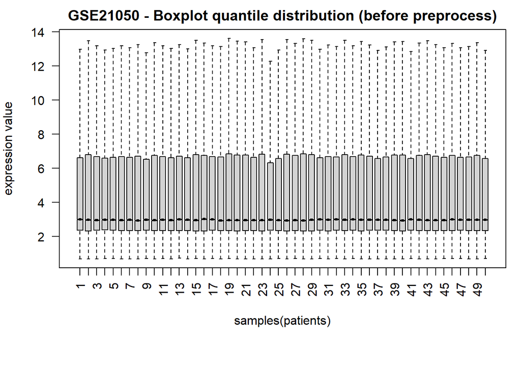

```r
# Grafico boxplot antes de la normalizacion
par(mar=c(7,4,2,1))
boxplot(t(gene_matrix2[1:nmax_boxplot,]), boxwex=0.7, notch=T,
        main=paste(dataset_name, "- Boxplot quantile distribution (before preprocess)"),
        xlab = "samples(patients)",
        ylab = "expression value",
        outline=FALSE, las=2)
```

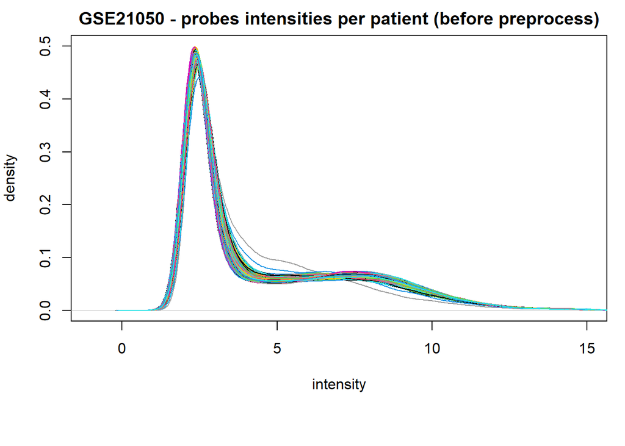

```r
# Grafico de densidades antes de la normalizacion
plot(density(unlist(gene_matrix2[1,]), na.rm = TRUE),
     main = paste(dataset_name, "- probes intensities per patient (before preprocess)"),
     xlim = log2_xlim_before, ylim = log2_ylim_before,
     xlab = "intensity",
     ylab = "density"
    )

for(i in 2:nrow(gene_matrix2)){
  lines(density(unlist(gene_matrix2[i,]), na.rm = TRUE), col = i)
}
```

```r
# La variabilidad experimental es baja, las distribuciones por cuantiles son uniformes. En este caso no necesitamos aplicar normalizacion por cuantiles
```

```r
if (do_norm=="YES"){
  # Aplicar normalizacion por cuantiles
  gene_matrix4aux_t <- normalize.quantiles(
    t(as.matrix(gene_matrix3)), copy=TRUE)
  rownames(gene_matrix4aux_t) <- colnames(gene_matrix3)
  gene_matrix4 <- t(gene_matrix4aux_t)

  # Grafico boxplot tras la normalizacion para ver que hemos reducido la variabilidad experimental
  par(mar=c(7,4,2,1))
  boxplot(t(gene_matrix4[1:nmax_boxplot,]), boxwex=0.7, notch=T,
        main=paste(dataset_name, "- Boxplot quantile distribution (after preprocess)"),
        xlab = "samples",
        ylab = "expression value",
        outline=FALSE, las=2)

  # Grafico de densidades tras la normalizacion para ver que hemos reducido la variabilidad experimental
  plot(density(unlist(gene_matrix4[1,]), na.rm = TRUE),
     main = paste(dataset_name, "- probes intensities (after preprocess)"),
     xlim = log2_xlim_after, ylim = log2_ylim_after,
     xlab = "intensity",
     ylab = "density"
     )

for(i in 2:nrow(gene_matrix4)){
  lines(density(unlist(gene_matrix4[i,]), na.rm = TRUE), col = i)
}

} else {
  gene_matrix4 <- gene_matrix3
}

# Almacenar la normalización por cuantiles en un dataset
not_gene_data4 <- not_gene_data3
dataset4 <- cbind(not_gene_data4,
                  gene_matrix4
            )

# Reordenar columnas
dataset4 <- dataset4 %>%
      dplyr::select(all_of(not_gene_columns), everything())
```

```r
# Almacenar en csv
write_csv(dataset4, paste0(dataset_files_folder_extraction,
                           dataset_name,"_4_normcuantiles.csv")
          )

write_csv(dataset4[,-which(names(dataset4) %in% not_gene_columns)],
          paste0(dataset_files_folder_extraction,
            dataset_name,"_4_normcuantiles_onlygene.csv")
          )
```

```r
# Mostrar los resultados

# Previsualizacion de las primeras filas y columnas (4x4) del conjunto de datos tras la normalizacion de cuantiles
print(head(dataset4[,1:4], n=4), digits = 2, right = TRUE, numb = 4)
```

```
##   group time_survivor 1007_s_at 1053_at
## 1     0          9.00       6.7     6.5
## 2     1          1.22       6.8     6.9
## 3     1          0.92       7.6     7.5
## 4     1          1.48       7.6     6.9
```

# Sumarización

Los conjuntos de datos de microarray en crudo no nos proporcionan información sobre los genes, si no sobre sondas. Cada una de estas sondas asociadas a un gen y hay múltiples sondas asociadas a un mismo gen.

En ella, resumimos bajo la media las sondas que corresponden a un mismo gen. Al transformar los atributos en genes, tenemos las características tal y como nos interesa estudiarlas y, además, al unificar valores se reduce la dimensión del problema.

En primer lugar, debemos de obtener una tabla de equivalencias sonda-gen. Esta equivalencia dependerá del tipo de plataforma de microarray utilizada durante el ensayo de laboratorio. Utilizando las herramientas de anotación de Bioconductor construimos una tabla de dos columnas, donde la primera indica la sonda y la segunda el gen asociado y almacenamos dicha tabla en un fichero .txt.

```r
# Tabla de equivalencias sonda gen para la plataforma de microarray utilizada

# Nombres de las sondas medidas
probes <- colnames(dataset4[,-which(names(dataset4) %in% not_gene_columns)])

# Extraer la notacion gene symbol a partir de las sondas
platform_db <- get(microarray_platform)
gene_symbols <- select(platform_db, keys = probes, columns = "SYMBOL", keytype = "PROBEID")
colnames(gene_symbols) <- c("From", "To")
gene_symbols$To <- sapply(strsplit(gene_symbols$To, "-"), "[", 1)
```

```r
# Guardar la equivalencia
write.table(gene_symbols,
            file = paste0(dataset_files_folder_extraction,
                          dataset_name,"_table_nomenclature.txt"),
            sep = "\t",
            row.names = FALSE)

# Ver la equivalencia sonda-gene symbol
# Previsualizacion de la tabla de equivalencias sonda-gen
print(tail(gene_symbols,10))
```

```
##             From           To
## 20025   78495_at       ZNF783
## 20026   79005_at      SLC35E1
## 20027   81737_at LOC100505915
## 20028   81811_at         <NA>
## 20029 89476_r_at       NPEPL1
## 20030   90265_at        ADAP1
## 20031   90610_at        LRCH4
## 20032   91617_at        DGCR8
## 20033 91684_g_at       EXOSC4
## 20034   91703_at      EHBP1L1
```

```r
print(gene_symbols)
```

```
##               From            To
## 1        1007_s_at          DDR1
## 2          1053_at          RFC2
## 3           117_at         HSPA6
## 4          1294_at          UBA7
## 5        1405_i_at          CCL5
## 6          1487_at         ESRRA
## 7     1552256_a_at        SCARB1
## 8     1552257_a_at        TTLL12
## 9     1552264_a_at         MAPK1
## 10      1552274_at           PXK
## 11    1552275_s_at           PXK
## 12    1552277_a_at       MSANTD3
## 13    1552287_s_at       AFG3L1P
## 14      1552291_at          PIGX
```

[output cut: 20020 more lines]

```r
# Llamar al script de Python desde R
file_source <- paste0(dataset_files_folder_preprocessing,
  dataset_name,"_4_normcuantiles_onlygene.csv"
  )
file_destination <- paste0(dataset_files_folder_preprocessing,
  dataset_name,"_5_sum_onlygene.csv")
file_nomenclature <- paste0(dataset_files_folder_preprocessing,
  dataset_name,"_table_nomenclature.txt")

comando <- paste("python", "../sumarizacion_sondas.py", file_source, file_destination, file_nomenclature)
system(comando)
```

```r
# Almacenar los datos en un dataframe
gene_matrix5 <- read_csv(
  paste0(dataset_files_folder_preprocessing, dataset_name,"_5_sum_onlygene.csv"),
  show_col_types = FALSE)

not_gene_data5 <- not_gene_data4

dataset5 <- cbind(not_gene_data5,
                  gene_matrix5
            )

# Reordenar columnas
dataset5 <- dataset5 %>%
      dplyr::select(all_of(not_gene_columns), everything())
```

```r
# Mostrar los resultados

cat("Numero de sondas antes de la sumarizacion: ", dim(gene_matrix4)[2], "\n")
```

```
## Numero de sondas antes de la sumarizacion:  19062
```

```r
cat("Numero de genes tras la sumarizacion: ", dim(gene_matrix5)[2], "\n")
```

```
## Numero de genes tras la sumarizacion:  10875
```

```r
# Previsualizacion del dataset tras la sumarizacion
print(head(dataset5[,1:4], n=4), digits = 2, right = TRUE, numb = 4)
```

```
##   group time_survivor A2M A4GALT
## 1     0          9.00  12    6.3
## 2     1          1.22  12    6.3
## 3     1          0.92  11    6.1
## 4     1          1.48  10    6.3
```

```r
# Almacenar en csv
write_csv(dataset5, paste0(dataset_files_folder_preprocessing,
  dataset_name,"_5_sum.csv")
  )
```

# Análisis diferencial

El análisis de expresión diferencial es un punto clave del preprocesamiento computacional. Consiste en identificar qué genes muestran cambios significativos en sus niveles de expresión bajo diferentes grupos biológicos. Para ello seguimos los siguientes pasos.

```r
# Matriz de diseño y de contraste

#  Creamos 2 grupos o niveles
groupsfactor <- as.factor(dataset5[,c("group")])
groups <- make.names(c("test","control"))
levels(groupsfactor) <- groups

# Matriz de diseno, introduciendo variables dummy
design_matrix <- model.matrix(~ -1 + groupsfactor)
colnames(design_matrix) <- levels(groupsfactor)

# Previsualizacion de la matriz de diseño
print(head(design_matrix))
```

```
##   test control
## 1    1       0
## 2    0       1
## 3    0       1
## 4    0       1
## 5    1       0
## 6    0       1
```

A partir de este contraste, ajustamos el modelo lineal y, mediante el método de bayes empírico verificaremos para qué genes hay evidencia estadística que diferenciación entre los dos grupos.

```r
# Ajustamos el modelo lineal
fit <- lmFit(t(gene_matrix5), design_matrix)

# Definimos el contraste: diferencia entre grupos
contrast_matrix <- makeContrasts(
  Diff = test - control,
  levels = design_matrix
)
contrast_matrix

# Ajustamos el modelo lineal para el contraste
fit2 <- contrasts.fit(fit, contrast_matrix)

# Aplicamos el metodo de Bayes empirico
fit3 <- eBayes(fit2)
```

[output not shown]

Tablas de decisión para identificar genes expresados: up, down or not-significative.

```r
# Decidimos que genes estan diferencialmente expresados
dT <- decideTests(fit3, adjust.method="fdr", p.value=0.05, return='integer')

dT_vector <- as.vector(dT)

dT_df <- data.frame(
  diffExp = dT_vector,
  row.names = row.names(dT)
)


# Previsualizacion de cuantos genes se expresan
print(summary(dT))
```

```
##        Diff
## Down    874
## NotSig 9496
## Up      505
```

```r
# Seleccionamos los genes diferencialmente expresados y filtramos los demas, construimos el dataframe
selected_columns <-  c(rep(TRUE, times=length(not_gene_columns)), ifelse(dT_vector==0, FALSE, TRUE))
    # seleccionar todas las caracteristicas y de los genes los diferencialmente expresados

dataset6 <- dataset5[, selected_columns]
gene_matrix6 <- dataset6[,-which(names(dataset6) %in% not_gene_columns)]
not_gene_data6 <- not_gene_data5

# Mostrar resultados
cat("Numero de genes antes del analisis diferencial: ", dim(gene_matrix5)[2], "\n")
```

```
## Numero de genes antes del analisis diferencial:  10875
```

```r
cat("Numero de genes antes del analisis diferencial: ", dim(gene_matrix6)[2], "\n")
```

```
## Numero de genes antes del analisis diferencial:  1379
```

```r
# Previsualizacion del dataset tras el analisis diferencial
print(head(dataset6[,1:4], n=4), digits = 2, right = TRUE, numb = 4)
```

```
##   group time_survivor AARSD1 ABCA8
## 1     0          9.00    6.8  11.4
## 2     1          1.22    6.7   7.9
## 3     1          0.92    7.0   2.4
## 4     1          1.48    6.3   2.5
```

```r
# Almacenamos cada gen junto con informacion sobre su expresion
write_csv(dT_df, file=paste0(dataset_files_folder_preprocessing,
  dataset_name,"_6_diffexp_decission.csv")
  )

write_csv(dataset6, file=paste0(dataset_files_folder_preprocessing,
  dataset_name,"_6_diffexp.csv")
  )
```

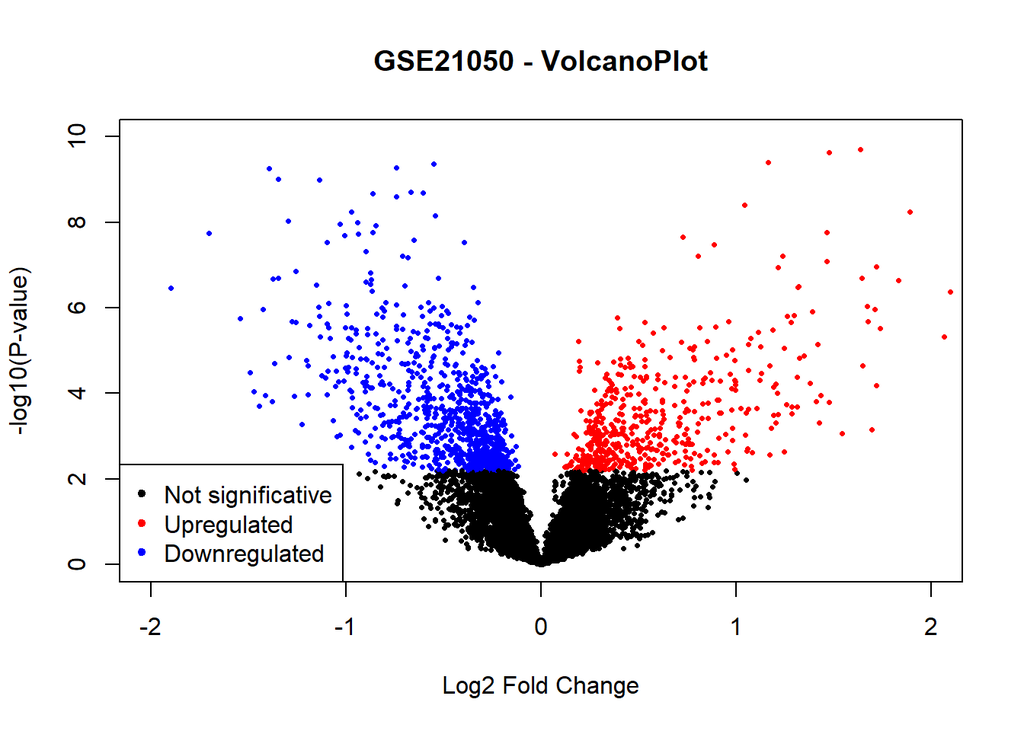

```r
# Graficamos los resultados

# Volcano plot
colores <- ifelse(dT_vector == 0, "black", ifelse(dT_vector == 1, "red", "blue"))

volcanoplot(fit3, coef=1,
            col=colores,
            main=paste(dataset_name,"- VolcanoPlot"),
            ph=20, cex = volcano_cex, xlim=volcano_xlim, ylim=volcano_ylim
            )
legend(volcano_legend, pch=20,
       col=c("black","red","blue"),
       legend=c("Not significative", "Upregulated", "Downregulated")
       )
```

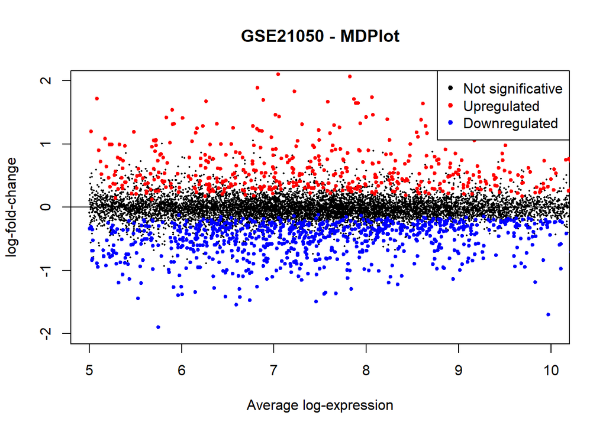

```r
# MD plot
plotMD(fit2, column=1,
       status=dT[,1],
       main=paste(dataset_name,"- MDPlot"),
       pch=20, cex=md_cex, xlim=md_xlim, ylim=md_ylim
       )
abline(h=0)
legend(md_legend, pch=20,
       col=c("black","red","blue"),
       legend=c("Not significative", "Upregulated", "Downregulated")
       )
```

# Nivel de dificultad del problema

Vamos a proyectar el problema en dos dimensiones para ver como de diferenciadas están las clases utilizando la librería umap.

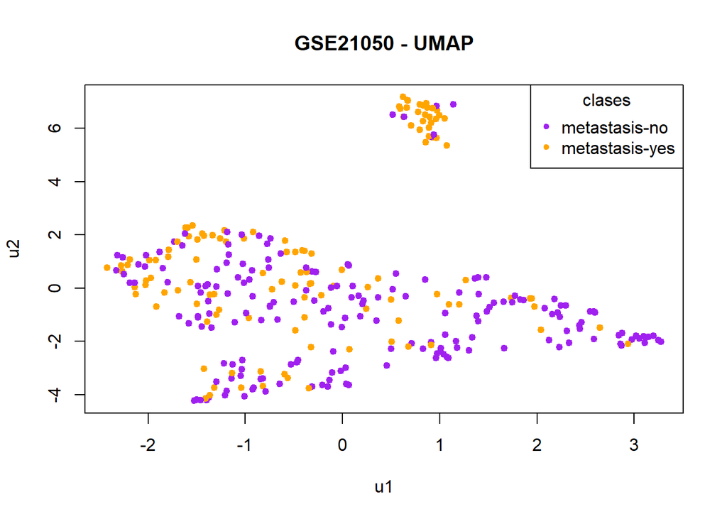

```r
umap_result <- umap(gene_matrix6, n_neighbors = 15, random_state = 42)
group_vector <- as.factor(ifelse(dataset6$group==0, groupv0, groupv1))

umap_df <- data.frame(
  u1 = umap_result$layout[, 1],
  u2 = umap_result$layout[, 2],
  group = as.factor(group_vector)
  )

plot(x=umap_df$u1, y=umap_df$u2,
     col = ifelse(dataset6$group==0, "purple", "orange"),
     pch = 20, cex=umap_cex,
     xlab="u1", ylab="u2", main=paste(dataset_name,"- UMAP")
     )
legend(umap_legend, legend = unique(umap_df$group),
       title = "clases",
       col = c("purple", "orange"),
       pch = 20
       )
```

___